# DATA 602 - Probability Models of Continuous Random Variables

# Introduction to Continuous Random Variables

Previouisly, you were subjected to discrete random variables of varying types. In every situation encountered, the result of the random experiment produced a *numerical outcome* that *could be* one of *finite* number of possible values. For example,

- the Bernoulli random variable has one of two possible values, $x = 0,1$
- the Binomial random variable will be one of $n$ possible values, $x = 0, 1, 2, \cdots, n$
- the Poisson random variable will be one of many *countably infinite* possible values, $x = 0, 1, 2, \cdots$

In each case, the numerical outcome captured by the random variable will be one of a finite or countably infinite number of points on the real number line. It is because of the *limited* number of possible numerical outcomes that the random variables encountered up to this point are categorized as **discrete random variables**.

In contrast, a **continuous randoom variable** produces the numerical outcome of a random experiment where there is no limit to the value of the numerical outcome. In short, a continuous random variable has an *infinite* number of possible outcomes. Some examples of continuous random variables are

- $X$ measures the household income (total annual income of all persons living in a certain household/residence) of a randomly chosen residence in Calgary
- $X$ records the amount of time you will spend to talk to a customer service representative when you call your financial institution
- $X$ is an observation of a randomly chosen patient’s systolic blood pressure

Another distinction between discrete random variables and continuous random variables is that a discrete random variables has a **probability distribution function**, whereas a continuous random variable has a **probability density function**. This probability density function - “pdf” for short- does not compute a probability, but rather is a function of the random variable that models its distribution/behavior of values. This leads us to the following definition

Let $X$ be a continuous random variable. A function $f(x)$ defined over the set of real numbers is called a **probability density function**of $X$ if and only if

1. $f(x)$ is non-negative. That is, $f(x) \geq 0$ for any $x$.
2. $\int_{-\infty}^{+\infty}f(x)dx = 1$

The set of real numbers that $f(x)$ is defined over is called the **support** of the probability density function.

## Working with Probability Density Functions

**Illustration 1:** A random variable $X$ has the following probability density function
$$f(x) = \frac{2x}{25} \hspace{0.5in} {\rm for\:\:} 0 \leq x \leq 5$$
The support of this probability density function is the values that prop it up, and those values are $0\leq x \leq 5$. Therefore,
$$\int_{0}^{5}\frac{2x}{25}dx = 1$$

and $f(x)$ is a probability density function. Below is a picture of what this probability density function looks like and a visual representation of how this partiuclar random variable behaves:

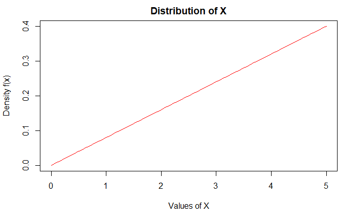

```r
firstden = function(x)  #create a function called firstden
{
  (2*x)/25    #the form of f(x)
}
curve(firstden, 0, 5, xlab="Values of X", ylab="Density f(x)", main="Distribution of X", col='red') #plot the function over its support
```

From this visualization, you can see that the “area” below the 45-degree line from the origin will be equal to 1. In other words, the area of this “triangle” is equal to 1. The area of any triangle is
$$Area = \frac{1}{2}*base*height$$
In this instance, $base = 5$, $height = 0.4$ and
$$Area = \frac{1}{2}*base*height = \frac{1}{2}*(5)*(0.4) = \frac{2}{2} = 1$$

**Result:** If $X$ is a continuous random variable having a probability density function $f(x)$, then for two constants $a$ and $b$ such that $a < b$
$$P(a \leq X \leq b) = P(a \leq X < b) = P(a < X \leq b) = P(a < X < b)$$
This result shows one of the fundamental differences between a continuous and discrete random variable. It $X$ is a discrete random variable, then
$$P(a \leq X \leq b) \ne P(a < X < b)$$
but rather
$$P(a \leq X \leq b) = P(a - 1 < X < b + 1)$$
Below are a few examples to get you familiar working with continuous random variables and their probability density functions, and using the “pdfs” to compute probabilities associated with the continuous random variable.
**Example 1** A random variable $X$ has the probability density function
$$f(x) = \frac{3x^{2}}{1000} \hspace{0.5in} {\rm for\:\:} 0 \leq x \leq 10$$

How this particular continuous random variable behaves is provided in the graph below.

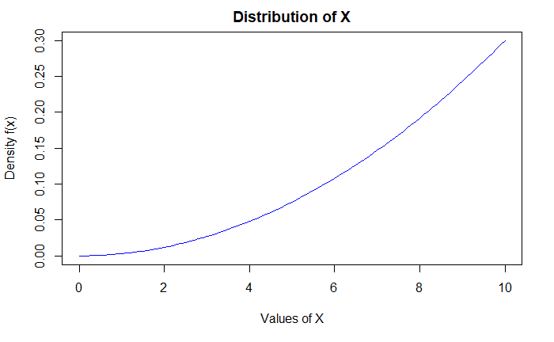

```r
den1 = function(x){3*(x^2)/1000 }   # create a function called den1
plot(den1, 0, 10, xlab="Values of X", ylab="Density f(x)", main="Distribution of X", col='blue')
```

You can see how this random variable $X$ is *left-skewed*, and the area beneath the curve between 0 and 10 is equal to 1, or
$$\int_{0}^{10}\frac{3x^{2}}{1000}dx = 1$$
This can be confirmed by having R carry out the integration for you using the `integrate` function:

```r
integrate(den1, lower=0, upper=10)$value   #integrate f(x) over its support, staring at 0 and ending at 10
```

```
[1] 1
```

**Application:** Suppose we wished to compute the probability that X will take on a value of 4 or more, that is compute $P(X \geq 4)$. Visually, you wish to find the size of the ,font color=‘red’>area to the right of 4 and the left of 10:

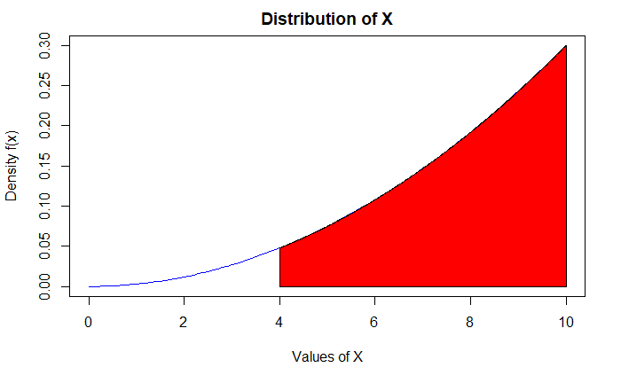

```r
den1 = function(x){3*(x^2)/1000 }   # create a function called den1
plot(den1, 0, 10, xlab="Values of X", ylab="Density f(x)", main="Distribution of X", col='blue')
cord.x = c(4, seq(4, 10, 0.01), 10)
cord.y = c(0, den1(seq(4, 10, 0.01)), 0)
polygon(cord.x,cord.y,col='red')
```

The computuation of $P(X \geq 4)$ is
$$\int_{4}^{10}\left(\frac{3x^{2}}{1000} \right)dx = \frac{3}{3000}\left[x^{3} \right]_{4}^{10} = \frac{3}{3000}[10^{3} - 4^{3}] = \frac{3}{3000}[1000 - 64] = \frac{3*(936)}{30000} = 0.936$$
You can do so with the following commands

```r
integrate(den1, lower=4, upper = 10)$value  # integrate the density function between 4 and 10
```

```
[1] 0.936
```

and
$$P(X \geq 4) = \int_{4}^{10}\frac{3x^{2}}{1000} = 0.936$$

Alternatively, this could have been computed with
$$\begin{align}
P(X \geq 4) = & 1 - P(X < 4) \\
= & 1 - \int_{0}^{4}\frac{3x^{2}}{1000} \\
\end{align}$$

Witin R, one can repeat the above series of commands

```r
den1 = function(x){3*(x^2)/1000 }
integrate(den1, lower=0, upper = 4)$value   #computes P(X < 4)
```

```
[1] 0.064
```

and
$$P(X \geq 4) = 1 - P(X< 4) = 1 - \int_{0}^{4}\frac{3x^{2}}{1000} = 1 - 0.064 = 0.936$$

**Time to Play 1:** Using the probability density function provided in Example 1, compute $P(6.5 \leq X \leq 9)$.

See the [link](http://people.ucalgary.ca/~jbstall/Answers/AnswerTimetoPlayCRV1.nb.html) to check your result.

**Example 2** A random variable $X$ measures the amount of time, in minutes, that it takes a person from their “check-in”" at the airline kiosk to passing through security at a large Canadian airport. The probability density function of $X$ is given as
$$f(x) = \left(\frac{1}{30}\right)e^{-\left(\frac{x}{30}\right)} \hspace{0.5in} x \geq 0$$
within R Studio, we will create the function appearing above **example2pdf**, then use this to compute the probability that

1. it takes a randomly chosen person between 20 and 40 minutes to pass through security from the time he/she has “checked-in” at the airline ticket kiosk.
2. it takes more than 10 minutes to pass through security from kiosk “check-in” time.

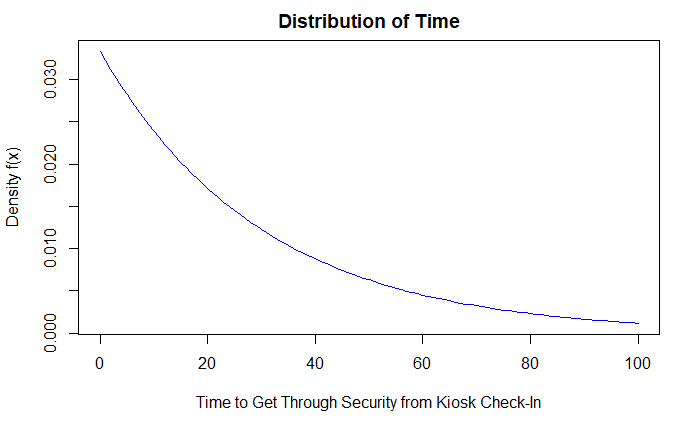

**Answer to part (a):** To compute the probability that it takes between 20 and 40 minutes to get from the kiosk check-in to pass security, you are required to compute $P(20 \leq X \leq 40)$, this is region is represented by the region below

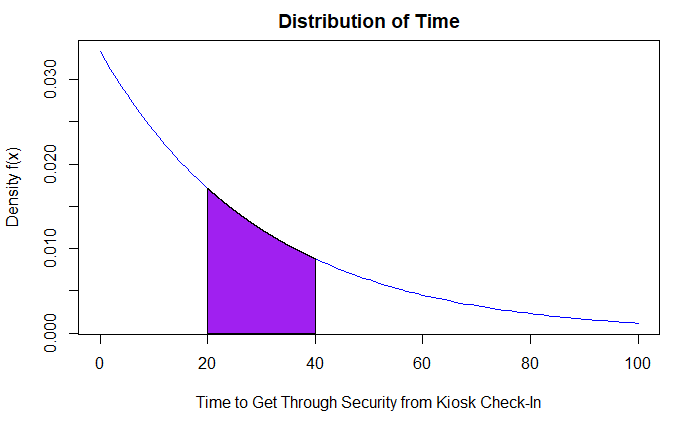

```r
exp(-2/3) - exp(-4/3)  #computes the expression appearing on the third line above
```

[output not shown]

```
[1] 0.24982
```

**Answer to part (b):** In this instance we are required to compute $P(X > 10)$:

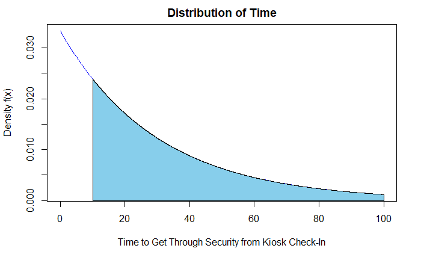

```r
integrate(example2pdf, lower=10, upper=10000)$value #computes P(X > 10)
```

[output not shown]

```
[1] 0.7165313
```

or

```r
1 - integrate(example2pdf, lower=0, upper=10)$value #computes P(X > 10)
```

```
[1] 0.7165313
```

**Time to Play 2:** Consider the random variable $X$ with the probability density function
$$f(x) = \left(\frac{1}{2}\right)x^{-3/2} \hspace{0.3in} \text{for}\: \: x \geq 1$$

1. Use R to create a function called `ttp2pdf`.
2. Use the `plot` command to visualize the behavior of this random variable.
3. Compute $P(2 \leq X \leq 4)$
4. Compute $(X \geq 3)$
5. Compute $P(2 \leq X \leq 4 |X < 3)$.

Refer to this [link](http://people.ucalgary.ca/~jbstall/Answers/AnswerTimetoPlayCRV2.nb.html) to affirm your result.

## The Cumulative Probability Density Function

Often we are interested in determining a **percentile** associated with a particular random variable. A percentile is a certain value/point of $X$ for which the probability of observance being is less than or equal to is of a particular probability. For example, suppose in the last example we were interested in the amount of time that it takes at most 80% of customers to pass through security once they have completed their kiosk check-in.

The **pth-percentile** $x_{p}$
$$P(X \leq x_{p}) = {\rm a\:\:given\:\:probability}$$

To find a certain percentcile of a random variable, we require its *cumulative probability distribuiton function*. The **cumulative probability distribution function** of a random variable $X$ is
$$F(x) = P(X \leq x) = \int_{-\infty}^{x}f(t)dt$$
*provided* the three conditions hold:

1. $lim_{x \rightarrow -\infty} F(x) = F(-\infty) = 0$
2. $lim_{x \rightarrow \infty} F(x) = F(\infty) = 1$
3. $F(x)$ is a non-decreasing function of x. For example, if $x_{1} < x_{2}$, then $F(x_{1}) < F(x_{2})$

Returning to the first example, where a random variable $X$ had the “pdf” $f(x) = \frac{2x}{25}$ for $0 \leq x \leq 5$. The cumulative distribuiton function of $X$, or $F(X)$ can be found using a bit of calculus:
$$\begin{align}
F(x) = & \int_{-\infty}^{x}\frac{2t}{25}dt \hspace{0.25in} {\rm replace \:\;x \:\: with\:\; t} \\
= & \int_{-\infty}^{0}0dt + \int_{0}^{x}\frac{2t}{25}dt \\
= & 0 + \frac{2}{25}\left( \frac{t^{2}}{2}_{0}^{x} \right) \\
= & \frac{2}{25} \left(\frac{x^{2}}{2} - \frac{0^{2}}{2} \right) \\
& \\
F(x) = & \frac{x^{2}}{25} \hspace{0.5in} {\rm for\:\:} 0 \leq x \leq 5
\end{align}$$

The graphs below show the differences between the “pdf” and the “cdf” for a random variable $X$ where
$$f(x) = \frac{2x}{25} \hspace{0.25in} {\rm for\:\:} 0 \leq x \leq 5; \hspace{0.25in} F(x) = \frac{x^2}{25} \hspace{0.2in} {\rm for\:\:}0\leq x \leq 5,$$

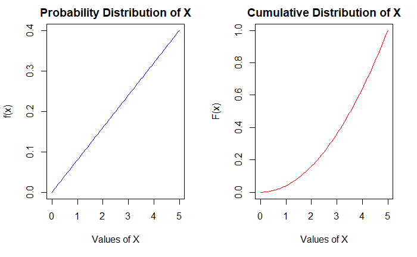

```r
par(mfrow=c(1,2))        #sets graphs to show 1 row with 2 graphs
den1= function(x){ (2*x/25) }      # the pdf function of x
curve(den1, 0, 5, xlab="Values of X", ylab="f(x)", main="Probability Distribution of X", col='blue') #graphs pdf
den2 = function(x){ (x^{2})/25 }   # the cdf function of x
curve(den2, 0, 5, xlab="Values of X", ylab="F(x)", main="Cumulative Distribution of X", col='red')  #graphs cdf
```

So what is this used for? Well, consider the computation of $P(X \leq 3)$:
$$P(X \leq 3) = \int_{0}^{3}\frac{2x}{25}dx = 0.36$$
This can be computed with the “cdf” $F(x)$
$$F(3) = P(X \leq 3) = \frac{3^{2}}{25} = \frac{9}{25} = 0.36$$
For this particular random variable, $x = 3$ represents the *36-th* pecentile, or $x_{36} = 3$. That is, 36% of the values of $X$ are less than or equal to $3$.

**Example 3:** Find the 50th-percentile, $x_{50}$ for the previous random variable having the cumulative distribution function $F(x) = \frac{x^{2}}{25}$.
**Solution:** To compute $x_{50}$, we set the value of the “cdf” of $X$ to be equal to 0.50 and then solve for $x_{50}$:
$$\begin{align}
F(x_{50}) = & P(X \leq x_{50}) \\
0.50 = & \frac{x_{50}^{2}}{25} \\
& \\
25 * 0.50 = & x_{50}^{2} \\
12.5 = & x_{50}^{2} \\
\sqrt{12.5} = & x_{50} \\
3.5355 = & x_{50}
\end{align}$$
The 50th percentile is then $x_{50} = 3.5355$. The probability that $X$ is *less than or equal to* 3.5355 is 0.50. As a “check”

```r
den11= function(x){ (2*x/25) } #create a function den1 that is the pdf of X
integrate(den1, lower = 0, upper = 3.5355)$value  #integrate pdf of X between 0 and 3.5355
```

```
[1] 0.4999904
```

One can develop the cumulative distribution function $F(X)$ from the probability density function $f(x)$, and then use the cumulative probability distribution function to compute $P(X \leq x_{0})$, where $x_{0}$ is certain value of $X$.

**Result:** If $F(x)$ is the cumulative distribution function, or `CDF’ of a continuous random variable $X$, then

$$P(a \leq X \leq b) = P(X\leq b) - P(X\leq a) = F(b) - F(a)$$

**Example 4:** Consider the random variable that measures the amount of time it takes an airline passenger to pass through security once they have checked in to their flight at the check-in kiosk. The “pdf” and “cdf” are given below, as well as visual representations of $f(x)$ and $F(x)$:

$$f(x) = \left(\frac{1}{30}\right)e^{-\left(\frac{x}{30}\right)} \hspace{0.25in} x \geq 0; \hspace{0.25in} F(x) = 1 - e^{(\frac{-x}{30})} \hspace{0.25in} x \geq 0$$
Visually, we see the difference between these two

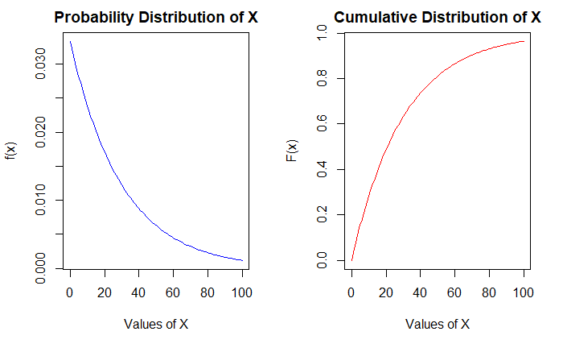

You can roughly see how the cumulative probabilites $P(X \leq x)$ change as the values of $X$ increase from the “cdf” graph on the right-hand side. From the graph, you can estimate that it takes at most 20 minutes to get from the check-in kiosk to the point where one is past security, or $P(X \leq 20)$, to about approximately somewhere between 0.045 and 0.50 (roughly!). To compute this probability you can evaluate $F(x)$ at $20$:
$$P(X \leq 20) = F(20) = 1 - e^{(\frac{-20}{30})} = 0.4866$$

Use the provided cumulative distribution function $F(x)$ to compute the probabilities posed in parts (a) through (b).

**Answer to (a):** To compute the probability that it takes between 10 and 20 minutes to pass through security, the $P( 10 < X < 20)$ needs to be computed. Remember that $P(10 < X < 20) = P( 10 \leq X \leq 20)$. Using the cumulative distribution function provided
$$\begin{aligned}
P( 10 < X < 20) = & P(X \leq 20) - P(X \leq 10) \\
= & F(20) - F(10) \\
= & (1 - e^{(\frac{-20}{30})}) - (1 - e^{(\frac{-10}{30})}) \\
= & e^{(\frac{-10}{30})})- e^{(\frac{-20}{30})}
\end{aligned}$$
The last line is computed in R

```r
exp(-10/30) - exp(-20/30)
```

```
[1] 0.2031142
```

and
$$P( 10 < X < 20) = e^{(\frac{-10}{30})})- e^{(\frac{-20}{30})} = 0.2031142 \approx 0.2031$$
It is not necessary, but for the sake of it, this probability can be verified through the foundational integration of the probability density function $f(x)$:
$$P(10 < X <20) = \int_{10}^{20}\left(\frac{1}{30}\right)e^{-\left(\frac{x}{30}\right)}dx = 0.2031 \:\:(\text{see the R code provided below})$$

```r
den3= function(x){ (1/30)*exp(-x/30) }      # the pdf function of x
integrate(den3, lower=10, upper=20)$value
```

```
[1] 0.2031142
```

**Time to Play 3:** A random variable has a probability density function $f(x)$ and the cmumulative probability distribution function $F(x)$ provided below:
$$f(x) = \frac{1}{x^{2}} \hspace{0.2in} \text{for}\:\: x \geq 1; \hspace{0.2in} \:\:\text{and} \:\:\hspace{0.2in} F(x) = 1 - \frac{1}{x} \hspace{0.2in} \text{for}\:\: x \geq 1;$$
The visualizations of both $f(x)$ and $F(x)$ are provided below.

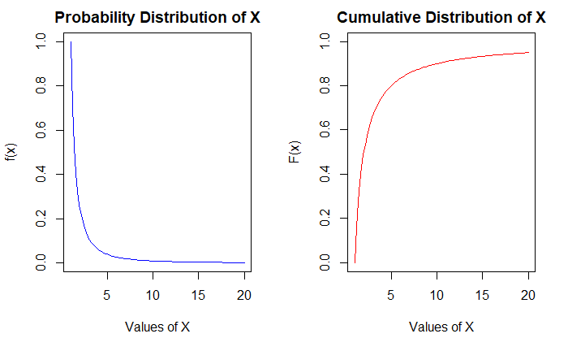

Employ your current comprehension of probability density functions and cumulative distribution functions to

1. compute $P(X \leq 4)$
2. compute $P(X > 10)$
3. compute $P(1 \leq X \leq 5)$
4. compute the median, or $x_{50}$.

See the [link](http://people.ucalgary.ca/~jbstall/Answers/AnswerTimetoPlayCRV3.nb.html) to affirm your result.

## The Expected Value and Standard Deviation of a Continuous Random Variable

We have seen how a continuous random variable has a “behaviour”, or distribution shape. When we first experience discrete random variables, we learned how there is there is also a (i) measure of centre and (ii) a measure of spread that go along with the distribution shape. The same holds true for continuous random variables that possess a probability density function $f(x)$.

**Result:** The mean/expected value of a continuous random variable having $f(x)$ is found by
$$\mu_{X} = E(X) = \int_{all\:\:x} xf(x)dx$$
and the standard deviation is found by

$$\sigma_{X} = \sqrt{Var(X)} \hspace{0.2in} {\rm where\:\:} Var(X) = E(X^{2}) - E(X)^{2} \:\: {\rm and\:\:} E(X^{2}) = \int_{all\:\:x} x^{2}f(x)dx$$
These formulae are used to compute the expected value/mean, second moment, variance, and standard devation. You have encountered these formula before for *discrete* random variables.

**Example 1(a):** Revisiting the “time to pass through security example”, how many minutes would you expect it to take for you to pass through security after you have checked-in to your flight at the kiosk?
**Solution:** We wish to compute $E(X)$ with
$$E(X) = \int_{0}^{\infty} x * \frac{1}{30}e^{\frac{-x}{30}}dx = ? \hspace{0.5in} (\text{carry out integration by parts....})$$
In R, simply re-create the function we have already created, multiplying this function by x:

```r
ev1= function(x){ x* (1/30)*exp(-x/30) }        # the pdf function f(x0x multiplied by x
integrate(ev1, lower = 0, upper =Inf)$value  # integret x*f(x) over the support of the pdf f(x)
```

```
[1] 30
```

Therefore, $E(X) = \int_{0}^{\infty} x * \frac{1}{30}e^{\frac{-x}{30}}dx = 30$. One would expect it to take 30 minutes to pass through security after they have checked into their flight via the kiosk.

**Example 1(b):** Using R Studio, compute the standard deviation.

```r
m2 = function(x){ x^2 * (1/30)*exp(-x/30) }      #a function that is x^{2}*f(x)
a = integrate(m2, lower = 0, upper = Inf)$value   # computes the 2nd momemt of x
stdev = sqrt(a - (30^2))                   # computes the squart of the variance
stdev
```

```
[1] 30
```

What we have done with the assistance of R is compute the following!

$$\sigma_{X} = \sqrt{Var(X)} = \sqrt{\underbrace{\left(\int_{0}^{\infty} x^{2} * \frac{1}{30}e^{\frac{-x}{30}}dx\right)}_{E(X^2)} - \underbrace{(30)^{2}}_{E(X)^2}} = 30$$

**Time to Play 4:** A random variable $X$ has the following probability density function
$$f(x) = \left \{
\begin{array}{ll}
e^{-x} & {\rm for\:\:} x \geq 0 \\
0 & {\rm otherwise} \\
\end{array}
\right.$$
The *cumulative* distribution function appears as

$$F(x) = P(X \leq x) = 1 - e^{-x} \hspace{0.5in} x > 0$$

Within R Studio compute

1. the mean/expected value $E(X)$.
2. the second moment $E(X^{2})$.
3. the standard deviation of $X$, $\sigma_{X}$.
4. Compute $P(X > 1)$
5. Compute $P(X > 2 |X > 1)$.

See the [link](http://people.ucalgary.ca/~jbstall/Answers/AnswerTimetoPlayCRV4.nb.html) to affirm your result.